# Variation in the FACE, PRICE and GOAT diphthongs in the adolescent data

Rosie Oxbury

January 2021

Load the packages we will need:

```r
library(tidyverse)
library(brms)
library(sjstats)
library(bayesplot)
library(bayestestR)
library(emmeans)
library(cowplot)
library(tidybayes)
```

# 1 Load data

```r
file_names <- list.files(path="data_separated")

data <- list()

for(i in 1:length(file_names)){
  name = paste("data_separated/", file_names[i], sep="")
  print(name)
  data[[file_names[i]]] <- read_csv(name)

}
```

```
[1] "data_separated/face_ad.csv"
```

```
[1] "data_separated/goat_ad.csv"
```

```
[1] "data_separated/price_ad.csv"
```

```r
#file.names <- dir(path, pattern =".rds")

#file.names
```

Check that this worked:

```r
typeof(data[[2]])
```

```
[1] "list"
```

Give names to the files in the list?

```r
real_names <- list.files(path="data_separated")

real_names2 <- str_replace(real_names, "\\.csv$", "")

names(data) <- real_names2
```

Check that this worked:

```r
names(data)
```

```
[1] "face_ad"  "goat_ad"  "price_ad"
```

```r
lapply(data, nrow)
```

```
$face_ad
[1] 2030

$goat_ad
[1] 1927

$price_ad
[1] 2380
```

Separate PRICE and *like*. Check how many different words are in the dataset beginning “lik…”:

```r
data$price_ad %>% filter(str_detect(word, "^LIK")) %>% group_by(word) %>% summarise(counts = n())
```

| word | counts |
| --- | --- |
| LIKE | 1053 |
| LIKED | 1 |
| LIKES | 3 |
| LIKING | 1 |

All of these should go into the *like* dataset, and be removed from the PRICE dataset.

```r
data$like_ad <- data$price_ad %>% filter(str_detect(word, "^LIK"))
data$price_ad <- data$price_ad %>% filter(!str_detect(word, "^LIK"))
```

Check number of rows

```r
lapply(data, nrow)
```

```
$face_ad
[1] 2030

$goat_ad
[1] 1927

$price_ad
[1] 1322

$like_ad
[1] 1058
```

# 2 Data cleaning and EDA

EDA checklist:

- check for NAs
- outliers, for all timepoints, both F1 and F2
- relevel preceding segment
- no preceding nasal or approximant
- relevel following segment
- check frequent words

Check for NAs first

```r
norm_formants <- c("normF1_20",
                   "normF1_35",
                   "normF1_50",
                   "normF1_65",
                   "normF1_80",
                   "normF2_20",
                   "normF2_35",
                   "normF2_50",
                   "normF2_65",
                   "normF2_80",
                   "norm_TL"
                   )

for(i in data){
  print(
  i %>% filter_at(vars(norm_formants), any_vars(is.na(.)))
  )
}
```

```
Note: Using an external vector in selections is ambiguous.
ℹ Use `all_of(norm_formants)` instead of `norm_formants` to silence this message.
ℹ See <https://tidyselect.r-lib.org/reference/faq-external-vector.html>.
```

| participant | vowel | sound_start | sound_end | task | word | utterance | F1_20 | F1_35 | F1_50 | F1_65 | F1_80 | F2_20 | F2_35 | F2_50 | F2_65 | F2_80 | fol.phonOLOG.seg | fol.PHONETIC.seg | prec.phonOLOG.seg | prec.PHONETIC.seg | normF1_20 | normF1_35 | normF1_50 | normF1_65 | normF1_80 | normF2_20 | normF2_35 | normF2_50 | normF2_65 | … |
| --- | --- | --- | --- | --- | --- | --- | --- | --- | --- | --- | --- | --- | --- | --- | --- | --- | --- | --- | --- | --- | --- | --- | --- | --- | --- | --- | --- | --- | --- | --- |

| participant | vowel | sound_start | sound_end | task | word | utterance | F1_20 | F1_35 | F1_50 | F1_65 | F1_80 | F2_20 | F2_35 | F2_50 | F2_65 | F2_80 | fol.phonOLOG.seg | fol.PHONETIC.seg | prec.phonOLOG.seg | prec.PHONETIC.seg | normF1_20 | normF1_35 | normF1_50 | normF1_65 | normF1_80 | normF2_20 | normF2_35 | normF2_50 | normF2_65 | … |
| --- | --- | --- | --- | --- | --- | --- | --- | --- | --- | --- | --- | --- | --- | --- | --- | --- | --- | --- | --- | --- | --- | --- | --- | --- | --- | --- | --- | --- | --- | --- |
| Tony | goat | 1563.581 | 1563.669 | interview | DON'T | I just don't give a c- I don't care like | 463.35 | NA | 412.73 | 128.07 | 689.6 | 769.77 | NA | 903.52 | 987.01 | 1073.84 | nt | n | d | d | 1.095732 | NA | 0.9760255 | 0.3028604 | 1.630769 | 0.5882882 | NA | 0.6905052 | 0.7543115 | … |

| participant | vowel | sound_start | sound_end | task | word | utterance | F1_20 | F1_35 | F1_50 | F1_65 | F1_80 | F2_20 | F2_35 | F2_50 | F2_65 | F2_80 | fol.phonOLOG.seg | fol.PHONETIC.seg | prec.phonOLOG.seg | prec.PHONETIC.seg | normF1_20 | normF1_35 | normF1_50 | normF1_65 | normF1_80 | normF2_20 | normF2_35 | normF2_50 | normF2_65 | … |
| --- | --- | --- | --- | --- | --- | --- | --- | --- | --- | --- | --- | --- | --- | --- | --- | --- | --- | --- | --- | --- | --- | --- | --- | --- | --- | --- | --- | --- | --- | --- |
| Chantelle | price | 329.122 | 329.456 | interview | BYE | we love you (( )) bye | NA | NA | NA | NA | NA | NA | NA | NA | NA | NA | 0 | 0 | b | b | NA | NA | NA | NA | NA | NA | NA | NA | NA | … |

| participant | vowel | sound_start | sound_end | task | word | utterance | F1_20 | F1_35 | F1_50 | F1_65 | F1_80 | F2_20 | F2_35 | F2_50 | F2_65 | F2_80 | fol.phonOLOG.seg | fol.PHONETIC.seg | prec.phonOLOG.seg | prec.PHONETIC.seg | normF1_20 | normF1_35 | normF1_50 | normF1_65 | normF1_80 | normF2_20 | normF2_35 | normF2_50 | normF2_65 | … |
| --- | --- | --- | --- | --- | --- | --- | --- | --- | --- | --- | --- | --- | --- | --- | --- | --- | --- | --- | --- | --- | --- | --- | --- | --- | --- | --- | --- | --- | --- | --- |

Get rid of the NA:

```r
data <- map(
  data,
  ~ filter_at(.x, vars(norm_formants), all_vars(!is.na(.)))
)
```

Check whether this worked:

```r
lapply(data, nrow)
```

```
$face_ad
[1] 2030

$goat_ad
[1] 1926

$price_ad
[1] 1321

$like_ad
[1] 1058
```

Names of items in “data” list:

```r
new_names <- names(data)
```

Check for outliers:

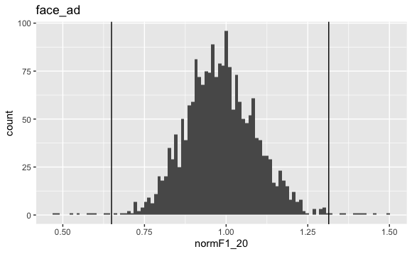

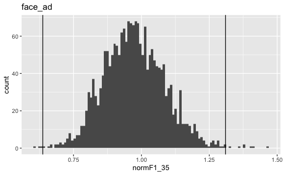

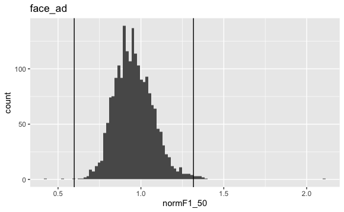

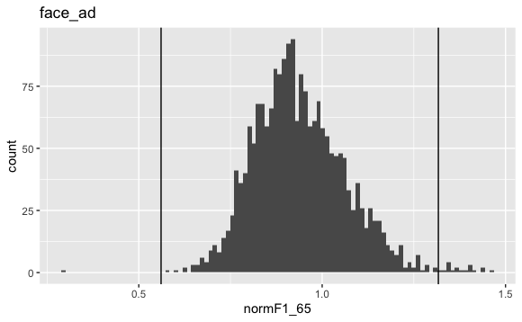

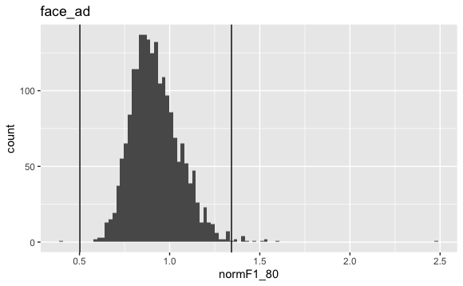

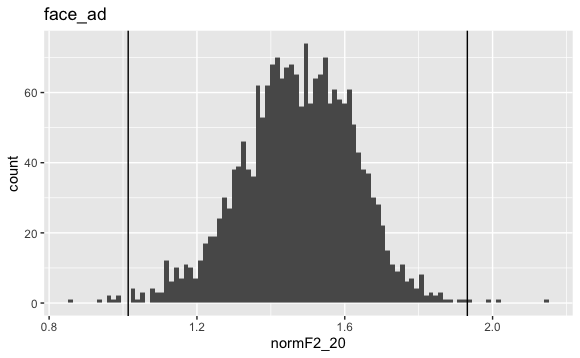

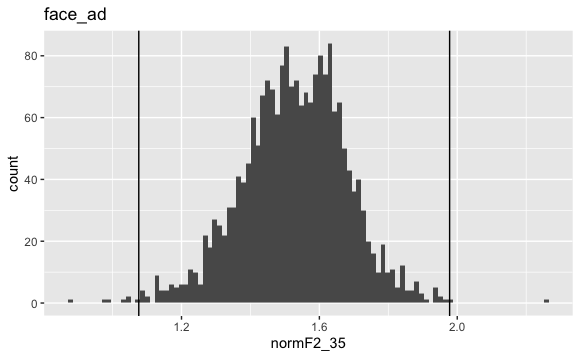

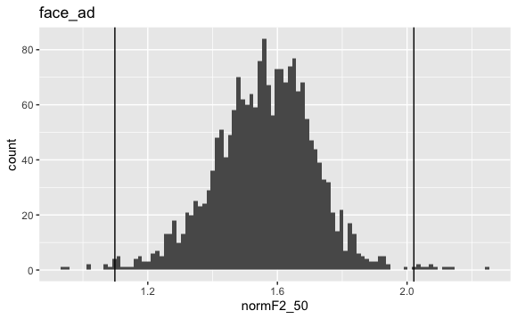

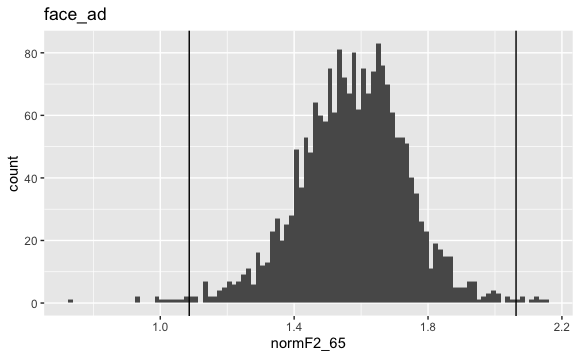

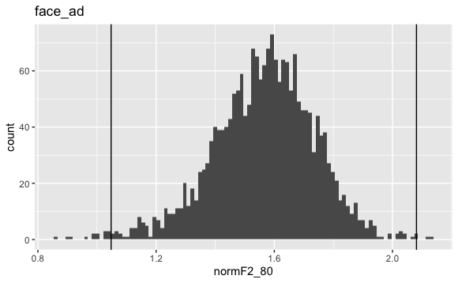

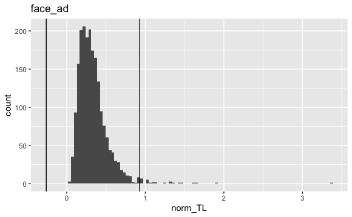

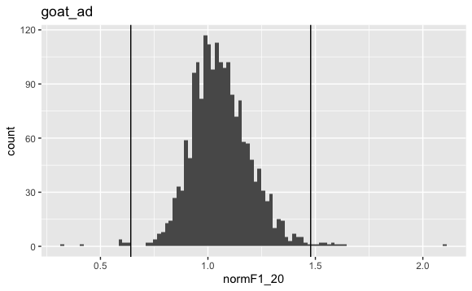

[32 more figures not shown]

```r
#map(data,
 #   ~ select(.x, vars(norm_formants)) %>% ggplot(aes())
  #              )


for(i in new_names){
  for(col in norm_formants){
 print(
  ggplot(data[[i]], aes(get(col))) +
      geom_histogram(bins=100) +
    xlab(col)+ggtitle(paste(i)) +
    geom_vline(xintercept = mean( data[[i]][[col]] ) - 3*sd(data[[i]][[col]])) +
    geom_vline(xintercept = mean( data[[i]][[col]] ) + 3*sd(data[[i]][[col]]))
  )
    }}
```

```r
data$face_ad <- data$face_ad %>% filter(
  normF1_50 < 1.5,
  normF1_65 > 0.5,
  normF1_80 < 2,
  normF2_65 > 0.8,
  norm_TL < 1.5
)

data$goat_ad <- data$goat_ad %>% filter(
  normF1_20 > 0.5,
  normF1_20 < 2,
  normF1_50 < 1.75,
  normF1_65 < 2,
  normF1_80 < 2,
  norm_TL < 2
)

data$price_ad <- data$price_ad %>% filter(
  normF1_20 < 2.2,
  normF1_65 > 0.5,
  normF1_65 < 2,
  norm_TL < 2
)

data$like_ad <- data$like_ad %>% filter(
  normF1_80 < 2,
  norm_TL < 1.5
)
```

```r
lapply(data, nrow)
```

```
$face_ad
[1] 2025

$goat_ad
[1] 1920

$price_ad
[1] 1312

$like_ad
[1] 1057
```

## 2.1 relevel following segment

```r
map(data,
    ~ group_by(.x, syl.type) %>% summarise(counts = n()))
```

| syl.type | counts |
| --- | --- |
| closed | 509 |
| coda.nasal | 260 |
| either | 28 |
| final.open | 700 |
| medial.open | 528 |

| syl.type | counts |
| --- | --- |
| closed | 238 |
| coda.nasal | 466 |
| either | 17 |
| final.open | 979 |
| medial.open | 220 |

| syl.type | counts |
| --- | --- |
| closed | 460 |
| coda.nasal | 273 |
| either | 6 |
| final.open | 446 |
| medial.open | 127 |

| syl.type | counts |
| --- | --- |
| closed | 1056 |
| medial.open | 1 |

```r
#table(data$price$syl.type)
```

```r
map(data,
    ~ filter(.x,
             syl.type=="either") %>% group_by(word) %>% summarise(unicorn=n()) %>% arrange(desc(unicorn))
)
```

| word | unicorn |
| --- | --- |
| OKAY | 26 |
| DAYLIGHT | 2 |

| word | unicorn |
| --- | --- |
| OKAY | 9 |
| SOLO | 3 |
| MICROPHONE | 2 |
| ASSOCIATE | 1 |
| ASSOCIATES | 1 |
| NOTIFY | 1 |

| word | unicorn |
| --- | --- |
| DAYLIGHT | 2 |
| MICROPHONE | 2 |
| NICELY | 1 |
| NOTIFY | 1 |

| word | unicorn |
| --- | --- |

```r
#data$price %>% filter(syl.type=="either") %>% group_by(word) %>% summarise(unicorn=n()) %>% arrange(desc(unicorn))
```

We will have to deal with these separately for each vowel, because the “either” class generally contains words that contain more than one of the target vowels.

First FACE:

```r
data$face_ad <- data$face_ad %>% mutate(
  syl.type2 = ifelse(
    syl.type=="closed", "closed",
    ifelse(
      syl.type=="coda.nasal", "coda.nasal",
      ifelse(
        syl.type=="final.open", "final.open",
        ifelse(syl.type=="medial.open", "medial.open",
               ifelse(syl.type=="either" & word== "OKAY", "final.open",
                      ifelse(syl.type=="either" & word=="DAYLIGHT", "medial.open", "other")
                      )
               )
        )
      )
  )
)
```

Then PRICE:

```r
data$price_ad <- data$price_ad %>% mutate(
  syl.type2 = ifelse(
    syl.type=="closed", "closed",
    ifelse(
      syl.type=="coda.nasal", "coda.nasal",
      ifelse(
        syl.type=="final.open", "final.open",
        ifelse(syl.type=="medial.open", "medial.open",
               ifelse(syl.type=="either" & word=="DAYLIGHT", "closed",
                      ifelse(
                        syl.type=="either" & word %in% c("MICROPHONE", "NICELY"), "medial.open",
                        ifelse(syl.type=="either" & word=="NOTIFY", "final.open", "other")
                        )
                      )))
      )
    )
  )
```

Now GOAT:

```r
data$goat_ad <- data$goat_ad %>% mutate(
  syl.type2 = ifelse(
    syl.type=="closed", "closed",
    ifelse(
      syl.type=="coda.nasal", "coda.nasal",
      ifelse(
        syl.type=="final.open", "final.open",
        ifelse(syl.type=="medial.open", "medial.open",
               ifelse(syl.type=="either" & word=="OKAY", "medial.open",
                      ifelse(syl.type=="either" & word=="SOLO", "other",
                             ifelse(syl.type=="either" & word=="MICROPHONE", "coda.nasal",
                                    ifelse(syl.type=="either" & word %in% c("ASSOCIATE", "ASSOCIATES", "NOTIFY"), "medial.open", "other")
                                           )
                                    )
                             )
               )
        )
      )
    )
  )
```

Create list of the vowels for which preceding and following environment is relevant:

```r
data_vowels <- list(
  "price_ad" = data$price_ad,
  "face_ad" = data$face_ad,
  "goat_ad" = data$goat_ad
)
```

Check how this worked:

```r
map(data_vowels,
    ~ group_by(.x, syl.type2) %>% summarise(counts = n()))
```

| syl.type2 | counts |
| --- | --- |
| closed | 462 |
| coda.nasal | 273 |
| final.open | 447 |
| medial.open | 130 |

| syl.type2 | counts |
| --- | --- |
| closed | 509 |
| coda.nasal | 260 |
| final.open | 726 |
| medial.open | 530 |

| syl.type2 | counts |
| --- | --- |
| closed | 238 |
| coda.nasal | 468 |
| final.open | 979 |
| medial.open | 232 |
| other | 3 |

```
NA
```

Get rid of the “others” in the GOAT set:

```r
data_vowels$goat_ad <- data_vowels$goat_ad %>% filter(!word =="SOLO")
```

Find out what the relevant coda segments are:

```r
map(data_vowels,
    ~ filter(.x, syl.type2=="closed") %>%
      mutate(fol.phonOLOG.seg = factor(fol.phonOLOG.seg)) %>%
    group_by(fol.phonOLOG.seg) %>% summarise(counts=n())
    )
```

| fol.phonOLOG.seg | counts |
| --- | --- |
| b | 2 |
| d | 107 |
| dz | 2 |
| f | 67 |
| fs | 1 |
| k | 6 |
| l | 1 |
| n | 1 |
| p | 19 |
| ps | 3 |

[output cut: 9 more lines]

| fol.phonOLOG.seg | counts |
| --- | --- |
| ? | 1 |
| d | 48 |
| dz | 5 |
| dʒ | 15 |
| f | 38 |
| k | 94 |
| ks | 13 |
| nd | 1 |
| p | 4 |
| pt | 22 |

[output cut: 9 more lines]

| fol.phonOLOG.seg | counts |
| --- | --- |
| 0 | 1 |
| d | 40 |
| dz | 11 |
| ðz | 2 |
| k | 22 |
| ks | 2 |
| kt | 2 |
| p | 11 |
| s | 5 |
| st | 38 |

[output cut: 8 more lines]

```
NA
```

Define vectors according to voicing/manner:

```r
voiced <-  c("b",
             "d",  "dz", "dʒ",
             "ðz",
             "v", "vd","vz",
             "z", "zd")
voiceless <- c("f", "fs",
               "k", "ks", "kt",
               "p", "ps", "pt",
               "s", "st", "sts",
               "t", "ts", "tʃ", "tʃt", "tθ",
               "θ")
nasal <- c("n", "nd")

other <- c("0", "?", "l")
```

Create the variable:

```r
data_vowels <- map(data_vowels,
                   ~ mutate(.x,
                     following = ifelse(
    syl.type2 =="coda.nasal", "coda.nasal",
    ifelse(
      syl.type2=="final.open", "final.open",
      ifelse(
        syl.type2=="medial.open", "medial.open",
        ifelse(
          syl.type2=="closed" & fol.phonOLOG.seg %in% voiced,
          "voiced",
          ifelse(
            syl.type2=="closed" & fol.phonOLOG.seg %in% voiceless,
            "voiceless",
            ifelse(
              syl.type2=="closed" & fol.phonOLOG.seg %in% nasal, "coda.nasal", "other"
            )
          )
        )
      )
    )
  )
                   ))
```

Check the output

```r
map(data_vowels,
    ~ group_by(.x, following) %>% summarise(counts=n())
    )
```

| following | counts |
| --- | --- |
| coda.nasal | 274 |
| final.open | 447 |
| medial.open | 130 |
| other | 3 |
| voiced | 204 |
| voiceless | 254 |

| following | counts |
| --- | --- |
| coda.nasal | 261 |
| final.open | 726 |
| medial.open | 530 |
| other | 1 |
| voiced | 185 |
| voiceless | 322 |

| following | counts |
| --- | --- |
| coda.nasal | 468 |
| final.open | 979 |
| medial.open | 232 |
| other | 1 |
| voiced | 104 |
| voiceless | 133 |

```
NA
```

Filter out “other”:

```r
data_vowels <- map(data_vowels,
                   ~ filter(.x,
                            following!="other"))
#data$price <- data$price %>% filter(following!="other")
```

Check that this worked:

```r
map(data_vowels,
    ~ group_by(.x, following) %>% summarise(counts=n())
    )
```

| following | counts |
| --- | --- |
| coda.nasal | 274 |
| final.open | 447 |
| medial.open | 130 |
| voiced | 204 |
| voiceless | 254 |

| following | counts |
| --- | --- |
| coda.nasal | 261 |
| final.open | 726 |
| medial.open | 530 |
| voiced | 185 |
| voiceless | 322 |

| following | counts |
| --- | --- |
| coda.nasal | 468 |
| final.open | 979 |
| medial.open | 232 |
| voiced | 104 |
| voiceless | 133 |

```
NA
```

And “other” is gone. Good. ## Relevel preceding segment

```r
map(data_vowels,
    ~ group_by(.x, prec.seg) %>% summarise(counts=n())
    )
```

| prec.seg | counts |
| --- | --- |
| approx.glide | 448 |
| coronal | 257 |
| labial | 171 |
| nasal | 270 |
| other | 47 |
| velar | 100 |
| vowel | 11 |
| zero | 5 |

| prec.seg | counts |
| --- | --- |
| approx.glide | 370 |
| coronal | 1090 |
| labial | 166 |
| nasal | 159 |
| other | 21 |
| velar | 170 |
| vowel | 39 |
| zero | 9 |

| prec.seg | counts |
| --- | --- |
| approx.glide | 132 |
| coronal | 727 |
| labial | 117 |
| nasal | 525 |
| other | 53 |
| velar | 282 |
| vowel | 58 |
| zero | 22 |

```
NA
```

I’ll probably put other, vowel and zero together.

## 2.2 Check frequent words

Check which words are most frequent

```r
map(data_vowels,
    ~ group_by(.x, word) %>% summarise(counts=n()) %>% arrange(desc(counts))
    )
```

| word | counts |
| --- | --- |
| MY | 138 |
| TIME | 97 |
| WHY | 90 |
| GUY | 64 |
| LIFE | 45 |
| BY | 41 |
| HIGH | 33 |
| FIGHT | 32 |
| TRIED | 28 |
| TRY | 28 |

[output cut: 200 more lines]

| word | counts |
| --- | --- |
| THEY | 332 |
| SAYING | 140 |
| SAY | 139 |
| SAME | 84 |
| BASICALLY | 67 |
| DAY | 53 |
| WAY | 49 |
| CAME | 46 |
| DAYS | 44 |
| CHANGE | 40 |

[output cut: 241 more lines]

| word | counts |
| --- | --- |
| DON'T | 306 |
| SO | 279 |
| NO | 210 |
| KNOW | 198 |
| GO | 173 |
| GOING | 50 |
| ONLY | 43 |
| BOTH | 36 |
| OVER | 35 |
| ROAD | 34 |

[output cut: 142 more lines]

```
NA
```

Leaving all these as they are for now, even though there are some extremely frequent function words within each vowel dataframe (“MY”, “THEY”, “DON’T” etc)

## 2.3 Create list of cleaned vowel dataframes:

```r
data_new <- list(
  "face_ad" = data_vowels$face_ad,
  "price_ad" = data_vowels$price_ad,
  "goat_ad" = data_vowels$goat_ad,
  "like_ad" = data$like_ad
)
```

## 2.4 Log-transform duration

Check distribution:

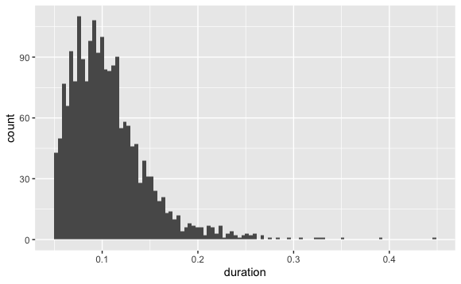

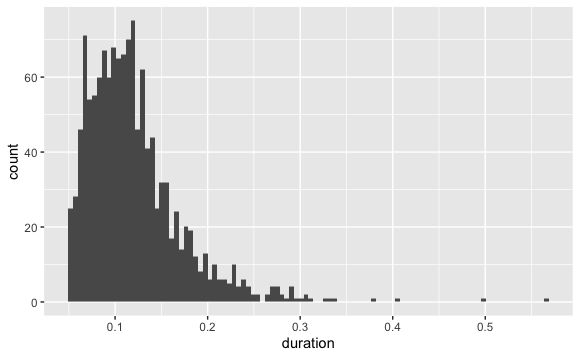

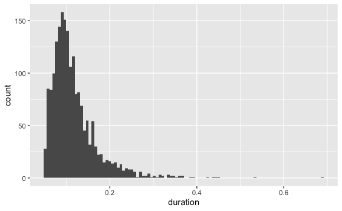

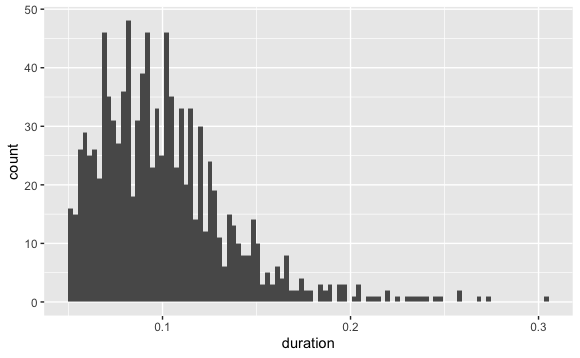

```r
map(data_new,
    ~ggplot(.x,
            aes(x=duration))+geom_histogram(bins=100))
```

```r
#ggplot(data$price, aes(x=duration))+geom_histogram(bins=100)+theme_minimal()
#ggplot(data$like, aes(x=duration))+geom_histogram(bins=100)+theme_minimal()
```

Taking the natural log, cos that’s what other studies do and say is standard.

```r
data_new <- map(data_new,
    ~ mutate(.x,
  LogDur = log(duration)
))
```

Check that it worked:

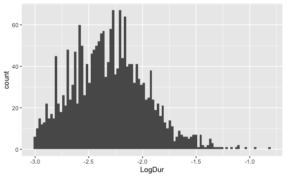

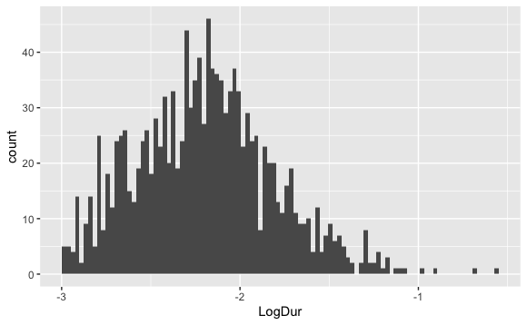

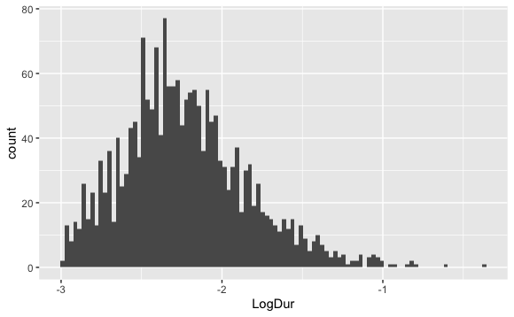

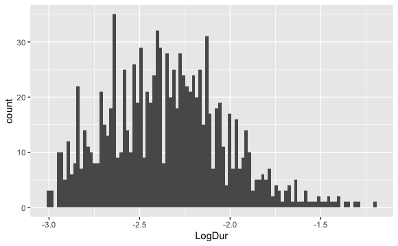

```r
map(data_new,
    ~ggplot(.x,
            aes(x=LogDur))+geom_histogram(bins=100))
```

A bit skewed. Cut out outliers – I don’t think we want any log(duration)s > -1:

```r
data_new <- map(data_new,
                ~ filter(.x,
                         LogDur < -1))
```

## 2.5 Relevel task

```r
map(data_new,
    ~group_by(.x, task) %>% summarise(counts=n()))
```

| task | counts |
| --- | --- |
| interview | 1710 |
| reading | 268 |
| wordlist | 44 |

| task | counts |
| --- | --- |
| interview | 1211 |
| reading | 72 |
| wordlist | 22 |

| task | counts |
| --- | --- |
| interview | 1729 |
| reading | 144 |
| wordlist | 35 |

| task | counts |
| --- | --- |
| interview | 1052 |
| reading | 1 |
| wordlist | 4 |

```r
#table(data$price$task)
#table(data$like$task)
```

Lump reading and wordlist together:

```r
# Make task a factor
data_new <- map(data_new,
    ~ mutate(.x,
      task = as.factor(task)
    ))

# Check current levels of task
lapply(data_new, function(x){levels(x$task)})
```

```
$face_ad
[1] "interview" "reading"   "wordlist"

$price_ad
[1] "interview" "reading"   "wordlist"

$goat_ad
[1] "interview" "reading"   "wordlist"

$like_ad
[1] "interview" "reading"   "wordlist"
```

```r
# Relevel. Slightly long-winded because levels() assignment doesn't work inside lapply() for some reason
data_new <- map(data_new,
                ~ mutate(.x,
                         task = ifelse(task=="interview", "interview",
                                       ifelse(task=="reading", "reading",
                                              ifelse(task == "wordlist", "reading", "other"))))
                )

# Unfortunately we now have to make it into a factor again
data_new <- map(data_new,
    ~ mutate(.x,
      task = as.factor(task)
    ))

# Check that this worked
lapply(data_new, function(x){levels(x$task)})
```

```
$face_ad
[1] "interview" "reading"

$price_ad
[1] "interview" "reading"

$goat_ad
[1] "interview" "reading"

$like_ad
[1] "interview" "reading"
```

Great. ## sum-code factors

The factors are: task, sex, CofP, outcode, following seg, prec.seg

Set task reference to interview.

```r
data_new <- map(data_new,
            ~mutate(.x,
                    task = relevel(task, ref="interview")
                    ))

#table(data$price$task)
#table(data$like$task)
```

In fact, make all of the other social factors factors:

```r
data_new <- map(data_new,
    ~ mutate(.x,
      sex = as.factor(sex),
      CofP = as.factor(CofP),
      outcode = as.factor(outcode)
      #levels(task) <- c("interview", "read.speech", "read.speech")
    ))
```

Sex:

```r
# Check existing contrasts
map(data_new,
    ~ contrasts(.x[["sex"]]))
```

```
$face_ad
  M
F 0
M 1

$price_ad
  M
F 0
M 1

$goat_ad
  M
F 0
M 1

$like_ad
  M
F 0
M 1
```

```r
# Assign contrasts. Got this code here: https://stackoverflow.com/questions/45140783/how-to-transform-a-string-into-a-factor-and-sets-contrasts-using-dplyr-magrittr
data_new <-  map(data_new,
                 ~ mutate(.x,
                          sex = factor(sex)) %>%
                   do({function(X) {
                     contrasts(X$sex) <- contr.sum(2); return(X)}}(.))
)



# Check that this worked
map(data_new,
    ~ contrasts(.x[["sex"]]))
```

```
$face_ad
  [,1]
F    1
M   -1

$price_ad
  [,1]
F    1
M   -1

$goat_ad
  [,1]
F    1
M   -1

$like_ad
  [,1]
F    1
M   -1
```

Same with CofP:

```r
# Check existing contrasts
map(data_new,
    ~ contrasts(.x[["CofP"]]))
```

```
$face_ad
          youthclub
studio            0
youthclub         1

$price_ad
          youthclub
studio            0
youthclub         1

$goat_ad
          youthclub
studio            0
youthclub         1

$like_ad
          youthclub
studio            0
youthclub         1
```

```r
# Assign contrasts. Got this code here: https://stackoverflow.com/questions/45140783/how-to-transform-a-string-into-a-factor-and-sets-contrasts-using-dplyr-magrittr
data_new <-  map(data_new,
                 ~ mutate(.x,
                          CofP = factor(CofP)) %>%
                   do({function(X) {
                     contrasts(X$CofP) <- contr.sum(2); return(X)}}(.))
)



# Check that this worked
map(data_new,
    ~ contrasts(.x[["CofP"]]))
```

```
$face_ad
          [,1]
studio       1
youthclub   -1

$price_ad
          [,1]
studio       1
youthclub   -1

$goat_ad
          [,1]
studio       1
youthclub   -1

$like_ad
          [,1]
studio       1
youthclub   -1
```

And outcode:

```r
# Check existing contrasts
map(data_new,
    ~ contrasts(.x[["outcode"]]))
```

```
$face_ad
  2 3
1 0 0
2 1 0
3 0 1

$price_ad
  2 3
1 0 0
2 1 0
3 0 1

$goat_ad
  2 3
1 0 0
2 1 0
3 0 1

$like_ad
  2 3
1 0 0
2 1 0
3 0 1
```

```r
# Assign contrasts. Got this code here: https://stackoverflow.com/questions/45140783/how-to-transform-a-string-into-a-factor-and-sets-contrasts-using-dplyr-magrittr
data_new <-  map(data_new,
                 ~ mutate(.x,
                          outcode = factor(outcode)) %>%
                   do({function(X) {
                     contrasts(X$outcode) <- contr.sum(3); return(X)}}(.))
)

# Check that this worked
map(data_new,
    ~ contrasts(.x[["outcode"]]))
```

```
$face_ad
  [,1] [,2]
1    1    0
2    0    1
3   -1   -1

$price_ad
  [,1] [,2]
1    1    0
2    0    1
3   -1   -1

$goat_ad
  [,1] [,2]
1    1    0
2    0    1
3   -1   -1

$like_ad
  [,1] [,2]
1    1    0
2    0    1
3   -1   -1
```

## 2.6 Preceding and following environment

Create list of dataframes for which this is relevant:

```r
data_new_no_like <- list(
  "face_ad" = data_new$face_ad,
  "price_ad" = data_new$price_ad,
  "goat_ad" = data_new$goat_ad
)
```

Check contrasts for preceding environment:

```r
# Check existing contrasts. Need to convert to factor first
data_new_no_like <- map(data_new_no_like,
    ~ mutate(.x,
             prec.seg = as.factor(prec.seg)))

map(data_new_no_like,
    ~ contrasts(.x[["prec.seg"]]))
```

```
$face_ad
             coronal labial nasal other velar vowel zero
approx.glide       0      0     0     0     0     0    0
coronal            1      0     0     0     0     0    0
labial             0      1     0     0     0     0    0
nasal              0      0     1     0     0     0    0
other              0      0     0     1     0     0    0
velar              0      0     0     0     1     0    0
vowel              0      0     0     0     0     1    0
zero               0      0     0     0     0     0    1

$price_ad
             coronal labial nasal other velar vowel zero
approx.glide       0      0     0     0     0     0    0
coronal            1      0     0     0     0     0    0
labial             0      1     0     0     0     0    0
nasal              0      0     1     0     0     0    0
other              0      0     0     1     0     0    0
velar              0      0     0     0     1     0    0
vowel              0      0     0     0     0     1    0
zero               0      0     0     0     0     0    1

$goat_ad
             coronal labial nasal other velar vowel zero
approx.glide       0      0     0     0     0     0    0
coronal            1      0     0     0     0     0    0
labial             0      1     0     0     0     0    0
nasal              0      0     1     0     0     0    0
other              0      0     0     1     0     0    0
velar              0      0     0     0     1     0    0
vowel              0      0     0     0     0     1    0
zero               0      0     0     0     0     0    1
```

Check how many in each category:

```r
map(data_new_no_like,
    ~ group_by(.x, prec.seg) %>% summarise(counts=n()))
```

| prec.seg | counts |
| --- | --- |
| approx.glide | 370 |
| coronal | 1088 |
| labial | 166 |
| nasal | 159 |
| other | 21 |
| velar | 170 |
| vowel | 39 |
| zero | 9 |

| prec.seg | counts |
| --- | --- |
| approx.glide | 445 |
| coronal | 257 |
| labial | 171 |
| nasal | 269 |
| other | 47 |
| velar | 100 |
| vowel | 11 |
| zero | 5 |

| prec.seg | counts |
| --- | --- |
| approx.glide | 132 |
| coronal | 725 |
| labial | 117 |
| nasal | 519 |
| other | 53 |
| velar | 282 |
| vowel | 58 |
| zero | 22 |

```
NA
```

Relevel in order to lump “other”, “vowel” amd “zero” together:

```r
data_new_no_like <-  map(data_new_no_like,
                 ~ do(.x, {function(X) {
                     levels(X$prec.seg) <- c("approx.glide",
                              "coronal",
                              "labial",
                              "nasal",
                              "other",
                              "velar",
                              "other",
                              "other" );
                     return(X)}}(.))
)

# Check that this worked
map(data_new_no_like,
    ~ table(.x[["prec.seg"]]))
```

```
$face_ad

approx.glide      coronal       labial        nasal        other
         370         1088          166          159           69
       velar
         170

$price_ad

approx.glide      coronal       labial        nasal        other
         445          257          171          269           63
       velar
         100

$goat_ad

approx.glide      coronal       labial        nasal        other
         132          725          117          519          133
       velar
         282
```

Great, looks like that worked. Now set the contrasts:

```r
# Check existing contrasts
map(data_new_no_like,
    ~ contrasts(.x[["prec.seg"]]))
```

```
$face_ad
             coronal labial nasal other velar
approx.glide       0      0     0     0     0
coronal            1      0     0     0     0
labial             0      1     0     0     0
nasal              0      0     1     0     0
other              0      0     0     1     0
velar              0      0     0     0     1

$price_ad
             coronal labial nasal other velar
approx.glide       0      0     0     0     0
coronal            1      0     0     0     0
labial             0      1     0     0     0
nasal              0      0     1     0     0
other              0      0     0     1     0
velar              0      0     0     0     1

$goat_ad
             coronal labial nasal other velar
approx.glide       0      0     0     0     0
coronal            1      0     0     0     0
labial             0      1     0     0     0
nasal              0      0     1     0     0
other              0      0     0     1     0
velar              0      0     0     0     1
```

```r
# Assign contrasts. Got this code here: https://stackoverflow.com/questions/45140783/how-to-transform-a-string-into-a-factor-and-sets-contrasts-using-dplyr-magrittr
data_new_no_like <-  map(data_new_no_like,
                 ~ mutate(.x,
                          prec.seg = factor(prec.seg)) %>%
                   do({function(X) {
                     contrasts(X$prec.seg) <- contr.sum(6); return(X)}}(.))
)

# Check that this worked
map(data_new_no_like,
    ~ contrasts(.x[["prec.seg"]]))
```

```
$face_ad
             [,1] [,2] [,3] [,4] [,5]
approx.glide    1    0    0    0    0
coronal         0    1    0    0    0
labial          0    0    1    0    0
nasal           0    0    0    1    0
other           0    0    0    0    1
velar          -1   -1   -1   -1   -1

$price_ad
             [,1] [,2] [,3] [,4] [,5]
approx.glide    1    0    0    0    0
coronal         0    1    0    0    0
labial          0    0    1    0    0
nasal           0    0    0    1    0
other           0    0    0    0    1
velar          -1   -1   -1   -1   -1

$goat_ad
             [,1] [,2] [,3] [,4] [,5]
approx.glide    1    0    0    0    0
coronal         0    1    0    0    0
labial          0    0    1    0    0
nasal           0    0    0    1    0
other           0    0    0    0    1
velar          -1   -1   -1   -1   -1
```

Find out the most frequent words in each preceding environment category

```r
precseg_levels <- levels(data_new_no_like$price_ad$prec.seg)
```

```r
#length(precseg_levels)

for(x in data_new_no_like){
  for(i in precseg_levels){
    print(x %>% filter(prec.seg==i) %>%
      group_by(prec.seg, word) %>%
      summarise(tokens = n()) %>%
      arrange(desc(tokens)))
  }
}
```

| prec.seg | word | tokens |
| --- | --- | --- |
| approx.glide | WAY | 49 |
| approx.glide | AWAY | 34 |
| approx.glide | LATER | 25 |
| approx.glide | RAISING | 23 |
| approx.glide | RACING | 21 |
| approx.glide | PLACE | 18 |
| approx.glide | PLAYING | 14 |
| approx.glide | WAIT | 11 |
| approx.glide | STRAIGHT | 10 |
| approx.glide | RACIST | 9 |

[output cut: 74 more lines]

| prec.seg | word | tokens |
| --- | --- | --- |
| coronal | THEY | 331 |
| coronal | SAY | 139 |
| coronal | SAYING | 137 |
| coronal | SAME | 84 |
| coronal | DAY | 53 |
| coronal | DAYS | 44 |
| coronal | CHANGE | 40 |
| coronal | TAKE | 32 |
| coronal | STAYED | 25 |
| coronal | SAFETY | 23 |

[output cut: 64 more lines]

| prec.seg | word | tokens |
| --- | --- | --- |
| labial | BASICALLY | 67 |
| labial | FACE | 15 |
| labial | PAY | 11 |
| labial | BAIT | 9 |
| labial | FAMOUS | 9 |
| labial | BABY | 7 |
| labial | FACEBOOK | 7 |
| labial | FAKE | 7 |
| labial | PAPER | 5 |
| labial | BASED | 4 |

[output cut: 17 more lines]

| prec.seg | word | tokens |
| --- | --- | --- |
| nasal | MAKE | 38 |
| nasal | MADE | 19 |
| nasal | NAME | 19 |
| nasal | MAKING | 12 |
| nasal | MAKES | 9 |
| nasal | MAYBE | 8 |
| nasal | MAINLY | 5 |
| nasal | NAMES | 5 |
| nasal | MAIN | 4 |
| nasal | EIGHTEEN | 3 |

[output cut: 26 more lines]

| prec.seg | word | tokens |
| --- | --- | --- |
| other | AGE | 9 |
| other | HATE | 7 |
| other | HATED | 7 |
| other | EIGHT | 5 |
| other | EIGHTEEN | 5 |
| other | ABLE | 3 |
| other | AIN'T | 3 |
| other | BEHAVIOUR | 3 |
| other | EIGHTY | 3 |
| other | SITUATION | 3 |

[output cut: 17 more lines]

| prec.seg | word | tokens |
| --- | --- | --- |
| velar | CAME | 46 |
| velar | GAVE | 26 |
| velar | OKAY | 26 |
| velar | ESCAPED | 22 |
| velar | GAY | 13 |
| velar | K | 6 |
| velar | CAKE | 5 |
| velar | GAME | 4 |
| velar | BECAME | 2 |
| velar | CASE | 2 |

[output cut: 15 more lines]

| prec.seg | word | tokens |
| --- | --- | --- |
| approx.glide | WHY | 90 |
| approx.glide | LIFE | 45 |
| approx.glide | TRIED | 28 |
| approx.glide | TRY | 28 |
| approx.glide | CRIED | 23 |
| approx.glide | RIGHT | 19 |
| approx.glide | WHITE | 13 |
| approx.glide | LIE | 12 |
| approx.glide | TRYING | 12 |
| approx.glide | LYING | 10 |

[output cut: 77 more lines]

| prec.seg | word | tokens |
| --- | --- | --- |
| coronal | TIME | 96 |
| coronal | SOMETIMES | 27 |
| coronal | TIMES | 17 |
| coronal | DIE | 15 |
| coronal | OUTSIDE | 12 |
| coronal | TYPE | 12 |
| coronal | INSIDE | 8 |
| coronal | SIDE | 8 |
| coronal | DIED | 7 |
| coronal | DIES | 4 |

[output cut: 37 more lines]

| prec.seg | word | tokens |
| --- | --- | --- |
| labial | BY | 41 |
| labial | FIGHT | 32 |
| labial | FIVE | 26 |
| labial | FIND | 15 |
| labial | BUY | 9 |
| labial | FIGHTS | 6 |
| labial | FIGHTING | 5 |
| labial | FINE | 5 |
| labial | BIKE | 4 |
| labial | SURVIVE | 3 |

[output cut: 20 more lines]

| prec.seg | word | tokens |
| --- | --- | --- |
| nasal | MY | 137 |
| nasal | NINE | 20 |
| nasal | KNIFE | 15 |
| nasal | MIND | 15 |
| nasal | MIGHT | 12 |
| nasal | NICE | 11 |
| nasal | MYSELF | 8 |
| nasal | NIGHT | 8 |
| nasal | KNIVES | 7 |
| nasal | NINETEEN | 5 |

[output cut: 23 more lines]

| prec.seg | word | tokens |
| --- | --- | --- |
| other | HIGH | 33 |
| other | IRISH | 7 |
| other | BEHIND | 5 |
| other | HIDE | 5 |
| other | ICE | 4 |
| other | EYES | 3 |
| other | EITHER | 1 |
| other | HYPER | 1 |
| other | IDEA | 1 |
| other | ISLANDS | 1 |

[output cut: 2 more lines]

| prec.seg | word | tokens |
| --- | --- | --- |
| velar | GUY | 64 |
| velar | KINDA | 11 |
| velar | GUY'S | 8 |
| velar | KIND | 7 |
| velar | KINDNESS | 4 |
| velar | GUYS | 3 |
| velar | DISGUISE | 1 |
| velar | MANKIND | 1 |
| velar | SKYPE | 1 |

| prec.seg | word | tokens |
| --- | --- | --- |
| approx.glide | ROAD | 34 |
| approx.glide | WON'T | 12 |
| approx.glide | CLOSE | 7 |
| approx.glide | LOADS | 7 |
| approx.glide | GROW | 5 |
| approx.glide | GROWN | 5 |
| approx.glide | GROWING | 4 |
| approx.glide | THROW | 4 |
| approx.glide | ALONE | 3 |
| approx.glide | BRO | 3 |

[output cut: 28 more lines]

| prec.seg | word | tokens |
| --- | --- | --- |
| coronal | DON'T | 306 |
| coronal | SO | 277 |
| coronal | SOCIAL | 22 |
| coronal | THOUGH | 18 |
| coronal | ONLY | 17 |
| coronal | ALSO | 14 |
| coronal | JOKING | 12 |
| coronal | SHOW | 9 |
| coronal | OVER | 8 |
| coronal | JOKE | 7 |

[output cut: 22 more lines]

| prec.seg | word | tokens |
| --- | --- | --- |
| labial | BOTH | 36 |
| labial | PHONE | 24 |
| labial | SPOKE | 8 |
| labial | POSTCODE | 6 |
| labial | ONLY | 4 |
| labial | FOCUS | 3 |
| labial | POLAR | 3 |
| labial | POLISH | 3 |
| labial | POSTCODES | 3 |
| labial | SUPPOSED | 3 |

[output cut: 18 more lines]

| prec.seg | word | tokens |
| --- | --- | --- |
| nasal | NO | 206 |
| nasal | KNOW | 197 |
| nasal | MOST | 23 |
| nasal | Y'KNOW | 21 |
| nasal | DUNNO | 11 |
| nasal | OVER | 11 |
| nasal | KNOWN | 6 |
| nasal | KNOWS | 6 |
| nasal | MOTIVE | 3 |
| nasal | NOSE | 3 |

[output cut: 22 more lines]

| prec.seg | word | tokens |
| --- | --- | --- |
| other | HOME | 26 |
| other | OVERCOMING | 22 |
| other | ONLY | 19 |
| other | HOMES | 17 |
| other | OWN | 16 |
| other | OKAY | 6 |
| other | OVER | 6 |
| other | HOPEFULLY | 5 |
| other | OPEN | 3 |
| other | OAK | 2 |

[output cut: 10 more lines]

| prec.seg | word | tokens |
| --- | --- | --- |
| velar | GO | 172 |
| velar | GOING | 50 |
| velar | GOES | 21 |
| velar | AGO | 7 |
| velar | OVER | 5 |
| velar | GOAT | 4 |
| velar | POSTCODE | 4 |
| velar | GHOSTS | 3 |
| velar | LINGO | 3 |
| velar | POSTCODES | 3 |

[output cut: 9 more lines]

Now the same process for following environment:

```r
map(data_new_no_like,
    ~ table(.x[["following"]]))
```

```
$face_ad

 coda.nasal  final.open medial.open      voiced   voiceless
        261         724         530         185         322

$price_ad

 coda.nasal  final.open medial.open      voiced   voiceless
        273         445         129         204         254

$goat_ad

 coda.nasal  final.open medial.open      voiced   voiceless
        468         971         232         104         133
```

Set the contrasts:

```r
# Assign contrasts. Got this code here: https://stackoverflow.com/questions/45140783/how-to-transform-a-string-into-a-factor-and-sets-contrasts-using-dplyr-magrittr
data_new_no_like <-  map(data_new_no_like,
                 ~ mutate(.x,
                          following = factor(following)) %>%
                   do({function(X) {
                     contrasts(X$following) <- contr.sum(5); return(X)}}(.))
)

# Check that this worked
map(data_new_no_like,
    ~ contrasts(.x[["following"]]))
```

```
$face_ad
            [,1] [,2] [,3] [,4]
coda.nasal     1    0    0    0
final.open     0    1    0    0
medial.open    0    0    1    0
voiced         0    0    0    1
voiceless     -1   -1   -1   -1

$price_ad
            [,1] [,2] [,3] [,4]
coda.nasal     1    0    0    0
final.open     0    1    0    0
medial.open    0    0    1    0
voiced         0    0    0    1
voiceless     -1   -1   -1   -1

$goat_ad
            [,1] [,2] [,3] [,4]
coda.nasal     1    0    0    0
final.open     0    1    0    0
medial.open    0    0    1    0
voiced         0    0    0    1
voiceless     -1   -1   -1   -1
```

Find out the most frequent words in each following environment category

```r
following_levels <- levels(data_new_no_like$price_ad$following)
```

```r
#length(precseg_levels)

for(x in data_new_no_like){
  for(i in following_levels){
    print(x %>% filter(following==i) %>%
      group_by(following, word) %>%
      summarise(tokens = n()) %>%
      arrange(desc(tokens)))
  }
}
```

| following | word | tokens |
| --- | --- | --- |
| coda.nasal | SAME | 84 |
| coda.nasal | CAME | 46 |
| coda.nasal | CHANGE | 40 |
| coda.nasal | NAME | 19 |
| coda.nasal | CHANGED | 8 |
| coda.nasal | AIN'T | 5 |
| coda.nasal | MAINLY | 5 |
| coda.nasal | NAMES | 5 |
| coda.nasal | GAME | 4 |
| coda.nasal | MAIN | 4 |

[output cut: 23 more lines]

| following | word | tokens |
| --- | --- | --- |
| final.open | THEY | 331 |
| final.open | SAY | 139 |
| final.open | DAY | 53 |
| final.open | WAY | 49 |
| final.open | AWAY | 34 |
| final.open | OKAY | 26 |
| final.open | GAY | 13 |
| final.open | STAY | 12 |
| final.open | PAY | 11 |
| final.open | K | 7 |

[output cut: 16 more lines]

| following | word | tokens |
| --- | --- | --- |
| medial.open | SAYING | 140 |
| medial.open | BASICALLY | 67 |
| medial.open | LATER | 25 |
| medial.open | RAISING | 23 |
| medial.open | RACING | 21 |
| medial.open | PLAYING | 14 |
| medial.open | MAKING | 12 |
| medial.open | FAMOUS | 9 |
| medial.open | RACIST | 9 |
| medial.open | BABY | 8 |

[output cut: 95 more lines]

| following | word | tokens |
| --- | --- | --- |
| voiced | DAYS | 44 |
| voiced | GAVE | 26 |
| voiced | STAYED | 25 |
| voiced | MADE | 19 |
| voiced | AGE | 13 |
| voiced | NOWADAYS | 10 |
| voiced | THEY'VE | 8 |
| voiced | RAISED | 6 |
| voiced | ALWAYS | 5 |
| voiced | ROLLERBLADES | 4 |

[output cut: 19 more lines]

| following | word | tokens |
| --- | --- | --- |
| voiceless | MAKE | 38 |
| voiceless | TAKE | 32 |
| voiceless | SAFETY | 23 |
| voiceless | ESCAPED | 22 |
| voiceless | PLACE | 18 |
| voiceless | FACE | 15 |
| voiceless | SAFE | 15 |
| voiceless | WAIT | 11 |
| voiceless | STRAIGHT | 10 |
| voiceless | BAIT | 9 |

[output cut: 49 more lines]

| following | word | tokens |
| --- | --- | --- |
| coda.nasal | TIME | 97 |
| coda.nasal | SOMETIMES | 27 |
| coda.nasal | NINE | 20 |
| coda.nasal | TIMES | 17 |
| coda.nasal | FIND | 15 |
| coda.nasal | MIND | 15 |
| coda.nasal | KINDA | 12 |
| coda.nasal | PRIMARY | 9 |
| coda.nasal | KIND | 7 |
| coda.nasal | BEHIND | 5 |

[output cut: 29 more lines]

| following | word | tokens |
| --- | --- | --- |
| final.open | MY | 137 |
| final.open | WHY | 90 |
| final.open | GUY | 64 |
| final.open | BY | 41 |
| final.open | HIGH | 33 |
| final.open | TRY | 28 |
| final.open | DIE | 15 |
| final.open | LIE | 12 |
| final.open | BUY | 9 |
| final.open | FLY | 3 |

[output cut: 10 more lines]

| following | word | tokens |
| --- | --- | --- |
| medial.open | TRYING | 12 |
| medial.open | IRISH | 11 |
| medial.open | LYING | 10 |
| medial.open | MYSELF | 8 |
| medial.open | FIGHTING | 5 |
| medial.open | DRIVER | 4 |
| medial.open | EITHER | 4 |
| medial.open | DRIVING | 3 |
| medial.open | DYING | 3 |
| medial.open | PRIVATE | 3 |

[output cut: 54 more lines]

| following | word | tokens |
| --- | --- | --- |
| voiced | TRIED | 28 |
| voiced | FIVE | 26 |
| voiced | CRIED | 23 |
| voiced | OUTSIDE | 12 |
| voiced | GUY'S | 8 |
| voiced | INSIDE | 8 |
| voiced | SIDE | 8 |
| voiced | DIED | 7 |
| voiced | KNIVES | 7 |
| voiced | ALIVE | 5 |

[output cut: 35 more lines]

| following | word | tokens |
| --- | --- | --- |
| voiceless | LIFE | 45 |
| voiceless | FIGHT | 32 |
| voiceless | RIGHT | 19 |
| voiceless | KNIFE | 15 |
| voiceless | WHITE | 13 |
| voiceless | MIGHT | 12 |
| voiceless | TYPE | 12 |
| voiceless | NICE | 11 |
| voiceless | ALRIGHT | 9 |
| voiceless | NIGHT | 8 |

[output cut: 32 more lines]

| following | word | tokens |
| --- | --- | --- |
| coda.nasal | DON'T | 306 |
| coda.nasal | ONLY | 43 |
| coda.nasal | HOME | 26 |
| coda.nasal | PHONE | 24 |
| coda.nasal | OWN | 18 |
| coda.nasal | HOMES | 17 |
| coda.nasal | WON'T | 12 |
| coda.nasal | KNOWN | 6 |
| coda.nasal | GROWN | 5 |
| coda.nasal | ALONE | 3 |

[output cut: 6 more lines]

| following | word | tokens |
| --- | --- | --- |
| final.open | SO | 277 |
| final.open | NO | 206 |
| final.open | KNOW | 197 |
| final.open | GO | 173 |
| final.open | Y'KNOW | 21 |
| final.open | THOUGH | 18 |
| final.open | ALSO | 14 |
| final.open | DUNNO | 11 |
| final.open | SHOW | 9 |
| final.open | AGO | 7 |

[output cut: 16 more lines]

| following | word | tokens |
| --- | --- | --- |
| medial.open | GOING | 50 |
| medial.open | OVER | 35 |
| medial.open | OVERCOMING | 22 |
| medial.open | SOCIAL | 22 |
| medial.open | JOKING | 12 |
| medial.open | OKAY | 9 |
| medial.open | GROWING | 4 |
| medial.open | BROKEN | 3 |
| medial.open | FOCUS | 3 |
| medial.open | LOCAL | 3 |

[output cut: 49 more lines]

| following | word | tokens |
| --- | --- | --- |
| voiced | ROAD | 34 |
| voiced | GOES | 21 |
| voiced | LOADS | 7 |
| voiced | THOSE | 7 |
| voiced | KNOWS | 6 |
| voiced | POSTCODE | 4 |
| voiced | NOSE | 3 |
| voiced | POSTCODES | 3 |
| voiced | SUPPOSED | 3 |
| voiced | CLOSE | 2 |

[output cut: 10 more lines]

| following | word | tokens |
| --- | --- | --- |
| voiceless | BOTH | 36 |
| voiceless | MOST | 23 |
| voiceless | SPOKE | 8 |
| voiceless | JOKE | 7 |
| voiceless | POSTCODE | 6 |
| voiceless | CLOSE | 5 |
| voiceless | HOPEFULLY | 5 |
| voiceless | GOAT | 4 |
| voiceless | GHOSTS | 3 |
| voiceless | OAK | 3 |

[output cut: 24 more lines]

## 2.7 Bind data for FACE, PRICE and GOAT back together with *like*

```r
data_new_new <- list(
  "face_ad" = data_new_no_like$face_ad,
  "price_ad" = data_new_no_like$price_ad,
  "goat_ad" = data_new_no_like$goat_ad,
  "like_ad" = data_new$like_ad
)
```

# 3 Modelling procedure

## 3.1 set priors

```r
my_priors <- c(
  set_prior("normal(0, 3)", class = "Intercept"), # intercept
  set_prior("normal(0, 3)", class = "b"), # beta
  #set_prior("normal(0, 1)", class = "sd"), # st. dev. of random effects
  #set_prior("normal(0, 1)", class = "sigma"), # sigma (overall error)
  set_prior("lkj(2)", class = "cor") # random effects correlation matrix
)
#Defaults:
#lkj(1) - cor
#student_t(3, 0, 10) Intercept
#student_t(3, 0, 10) sd
# student_t(3, 0, 10) sigma

# Different priors for *like* because it doesn't need a random effects correlation matrix
```

## 3.2 Convert TL to log(TL) and check distribution

Create log-transformed Trajectory Length variable:

```r
data_new_new <- map(data_new_new,
                    ~ mutate(.x,
                             LogTL = log(norm_TL)))
```

Check how this worked by plotting histograms:

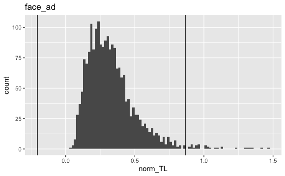

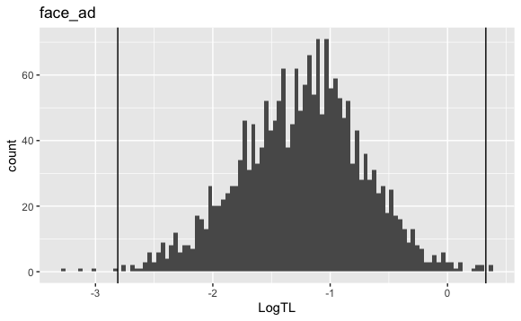

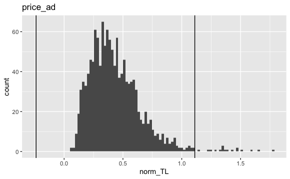

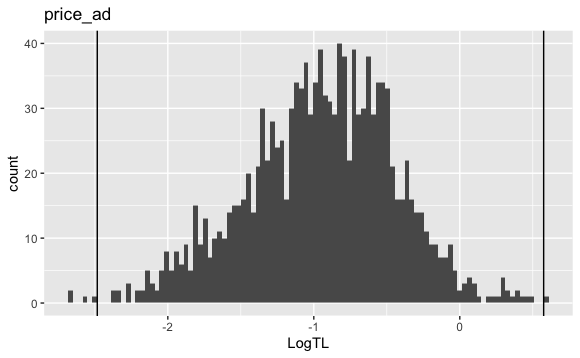

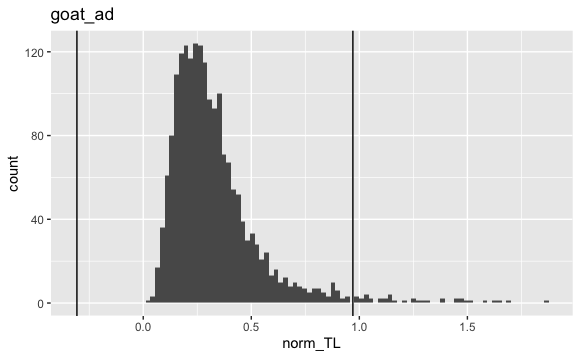

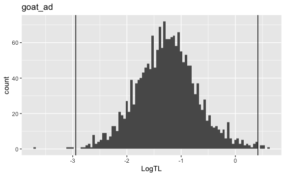

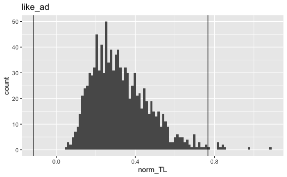

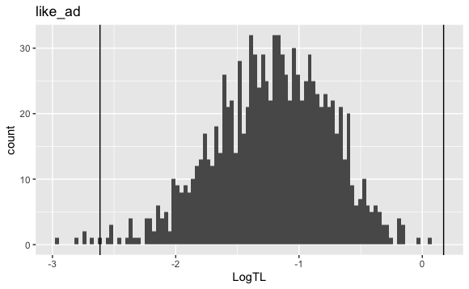

```r
# Names of dataframes
data_names <- names(data_new_new)
vars_to_plot <- c("norm_TL", "LogTL")

for(i in data_names){
  for(v in vars_to_plot){
 print(
  ggplot(data_new_new[[i]], aes(get(v))) +
      geom_histogram(bins=100) +
    xlab(v)+ggtitle(paste(i)) +
    geom_vline(xintercept = mean( data_new_new[[i]][[v]] ) - 3*sd(data_new_new[[i]][[v]])) +
    geom_vline(xintercept = mean( data_new_new[[i]][[v]] ) + 3*sd(data_new_new[[i]][[v]]))
  )
    }}
```

Get rid of the GOAT outlier(s):

```r
nrow(data_new_new$goat_ad)
```

```
[1] 1908
```

```r
data_new_new$goat_ad <- data_new_new$goat_ad %>% filter(LogTL > -3.1)
nrow(data_new_new$goat_ad)
```

```
[1] 1906
```